# Basic Concept of Deep Learning

June 6, 2018

## Perceptron

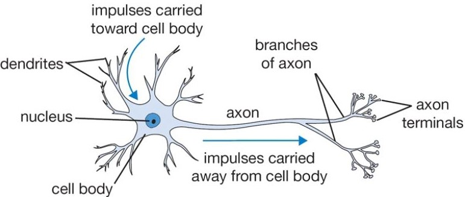

**Perceptron**: a single artificial neuron, belongs to the category of supervised learning algorithms (single-layer binary linear classifiers)

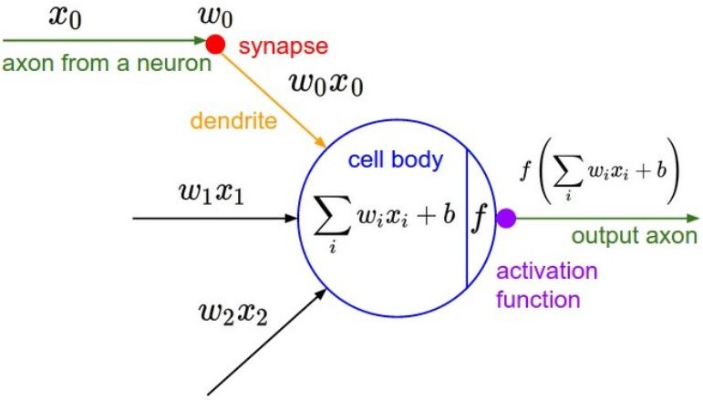

\(x_i\) = input  
\(w_i\) = weight factor  
\(b\) = bias term  
\(f\) = activation function

## Activation Functions

A function used to transform the activation level of a unit (neuron) into an output signal

**Common Activation Functions**:

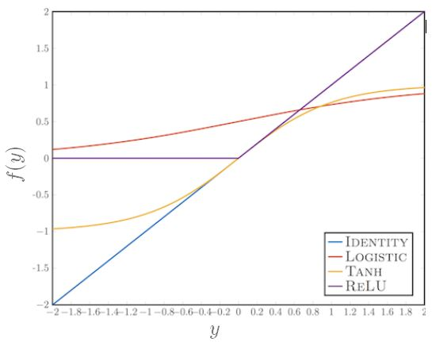

**Identity**: \(f(y) = y\)  
**Sigmoid**:  
- logistic function: \(f(y) = \frac{1}{1+e^{-y}}\)  
- hyperbolic tangent: \(f(y) = \tanh y\)  
**Rectified linear (ReLU)**: \(f(y) = \max (0,y)\)

## Sigmoid Logistic Function

General Linear Regression model: \(y = \sum_{i=0}^{n} w_ix_i\)

Probability: \(0 \leq p \leq 1\)  
Logistic Regression model: \(p(y|x) = \frac{e^y}{e^y+1}=\frac{1}{1+e^{-y}}\)

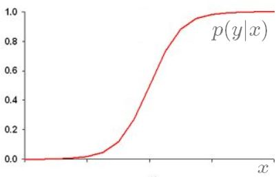

## Derivative of sigmoid function

\(p' = \frac{dp}{dy} =\frac{d}{dy}\frac{1}{1+e^{-y}} = \frac{d}{dy} a^{-1}\) with \(a = 1+e^{-y}\)

\(\frac{da}{dy} =-e^{-y}\)  
\(\frac{dp}{da} =\frac{d}{da} a^{-1} = -a^{-2} = -(1+e^{-y})^{-2}\)

\(\frac{dp}{dy} = \frac{dp}{da} \cdot \frac{da}{dy} = -(1+e^{-y})^{-2}\cdot(-e^{-y})= e^{-y}(1+e^{-y})^{-2}\)  
\(\frac{dp}{dy}=\frac{e^{-y}}{(1+e^{-y})^2} = \frac{1}{1+e^{-y}}\cdot \frac{e^{-y}}{1+e^{-y}} = \frac{1}{1+e^{-y}}\cdot \frac{1+e^{-y}-1}{1+e^{-y}}\)  
\(\frac{dp}{dy}= \frac{1}{1+e^{-y}}\cdot (\frac{1+e^{-y}}{1+e^{-y}} -\frac{1}{1+e^{-y}}) = p(1-p)\)

\[p' = p(1-p)\]